# How to do BirdNET validation

Sunny Tseng

2024-11-15

## BirdNET Quick Review

After processing audio files with BirdNET, a detection table is generated. This table includes columns detailing where each detection occurred (file name, start time, and end time), the detected species name, and a “confidence” score. The confidence score ranges from 0.1 to 1, indicating the likelihood that a detection is accurate.

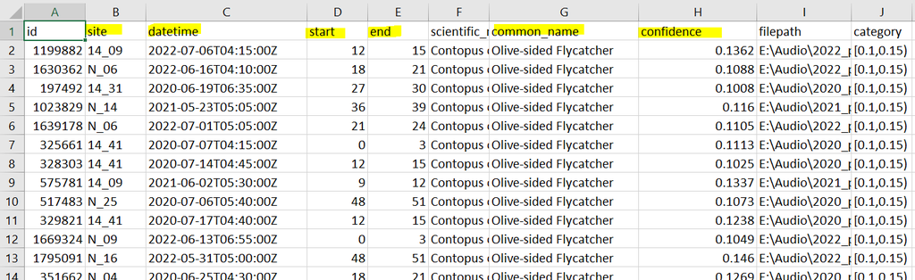

However, there is no established “threshold” for users to determine which detections to trust. Setting a high threshold can increase precision but may exclude valid detections, while a low threshold retains more detections but may lower precision. A species-specific threshold can be identified by creating a calibration curve that links BirdNET confidence scores to true positive probabilities, though this process requires a validated dataset.

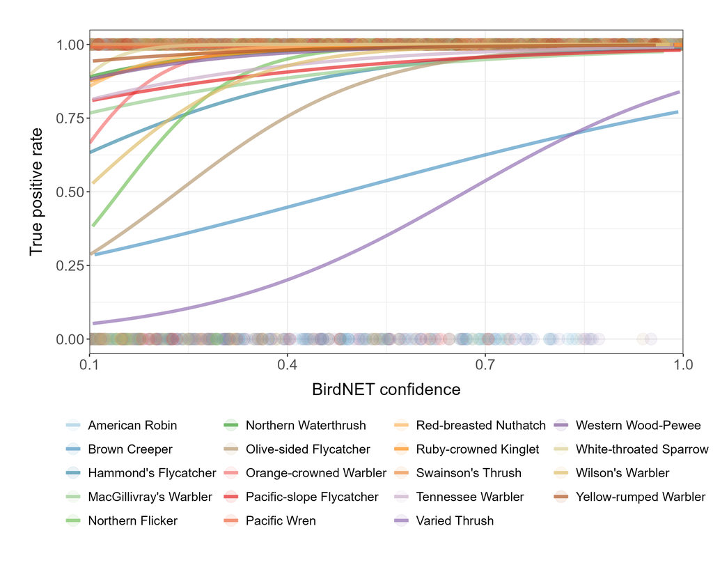

## Validation Steps

All validation datasets are stored in a [Google Drive](https://drive.google.com/drive/folders/1y5mlKvnEp9t8HED9-M25pRX1BoReqx8V?usp=sharing), organized by species in individual folders. Each species folder includes up to 360 recording segments (each 9 seconds long) and a .csv file named “SPECIES NAME_validation.csv” that serves as metadata for these segments. The segments are randomly selected from all detections for that species, stratified by confidence score. The validation task involves listening to each segment to verify if BirdNET correctly identified the species and writing down this information in the .csv file.

To conduct species validation, follow these steps:

- In the species folder, download and open the “SPECIES NAME_validation.csv” file. Add two new columns beside the category column labeled “validation” and “note.”

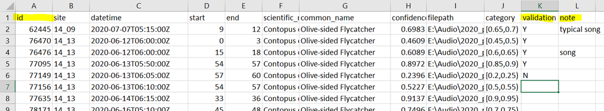

- Listen to each recording and view the spectrogram if needed. If the BirdNET detection is accurate (e.g., Olive-sided Flycatcher is present in the recording), enter “Y” in the validation column. If it is not accurate (e.g., no Olive-sided Flycatcher was heard), enter “N.”
  - To avoid judgement bias, “hide” the confidence column by `right click > Hide`.
  - A helpful tip: sort the .csv file by ID to match the sequence of the segments in the folder.
  - Can try downloading the files or listening to them on browser to see which makes you more comfortable. I personally liked to download them as it’s quicker if I need to check the spectrogram in Audacity.
- Record notes if there is any special vocalizations (e.g., call, begging call, high quality signals) and/or possible reasons for misidentification (e.g., background noise, misidentified as XYZ species).
  - Both [Xeno-Canto](https://xeno-canto.org/species/Contopus-cooperi?view=3) and [All About Birds](https://www.allaboutbirds.org/guide/Olive-sided_Flycatcher/sounds) have good examples of vocalizations.
- After completing all the segments, save your file as “SPECIES_NAME_validation_YOUR_INITIAL.csv” and upload it to the species folder.

## Updates

- [Here](https://github.com/SunnyTseng/thesis_aru_biodiversity_hotspot_V1/blob/main/data/Bird_list/species_list_final.csv) is the full list of species (122 species in total), feel free to let me know the species you wanted to do next. I will update the species recording segments on the Google Drive. (I didn’t upload all as the file size is too large)
- Let me know roughly how long it will take for you to finish each species. :)